# BC LTC Analysis

KT Hobbs

02/08/2020

## Import and prepare the data

```r
library(skimr)

# Import the data
df <- read.csv("../data/BC/bc_ltc_complete_kt.csv", na.strings="", header=TRUE)
colnames(df)
```

[output not shown]

```r
# assess ROOMS and BEDS_TOTAL
cor(df[, c(16:19)], use = "pairwise.complete.obs")
```

```
##               BEDS_TOTAL ROOMS_PRIVATE  ROOMS_SEMI ROOMS_MULTI
## BEDS_TOTAL     1.0000000    0.64513669  0.40591950   0.2712741
## ROOMS_PRIVATE  0.6451367    1.00000000 -0.04380106  -0.3000753
## ROOMS_SEMI     0.4059195   -0.04380106  1.00000000   0.1080358
## ROOMS_MULTI    0.2712741   -0.30007528  0.10803585   1.0000000
```

```r
# assess complaints and subcomplaints
df$COMPLAINTS <- as.numeric(as.character(df$COMPLAINTS))
df$SUB_COMPLAINTS <- as.numeric(as.character(df$SUB_COMPLAINTS))
cor(df[, c(10:15)], use = "pairwise.complete.obs")
```

```
##                      DCH_NURSE_LASTYR DCH_ALLIED_LASTYR DCH_TOTAL_LASTYR
## DCH_NURSE_LASTYR           1.00000000        0.05657024        0.9574867
## DCH_ALLIED_LASTYR          0.05657024        1.00000000        0.3420167
## DCH_TOTAL_LASTYR           0.95748674        0.34201672        1.0000000
## DCH_NURSE_CURRENTYR        0.84557883       -0.07666226        0.7738975
## DCH_ALLIED_CURRENTYR      -0.01858961        0.82724084        0.2217383
## DCH_TOTAL_CURRENTYR        0.84460522        0.14297737        0.8364984
##                      DCH_NURSE_CURRENTYR DCH_ALLIED_CURRENTYR
## DCH_NURSE_LASTYR              0.84557883          -0.01858961
## DCH_ALLIED_LASTYR            -0.07666226           0.82724084
## DCH_TOTAL_LASTYR              0.77389748           0.22173831
## DCH_NURSE_CURRENTYR           1.00000000          -0.14538458
## DCH_ALLIED_CURRENTYR         -0.14538458           1.00000000
## DCH_TOTAL_CURRENTYR           0.96485884           0.11961684
##                      DCH_TOTAL_CURRENTYR
## DCH_NURSE_LASTYR               0.8446052
## DCH_ALLIED_LASTYR              0.1429774
## DCH_TOTAL_LASTYR               0.8364984
## DCH_NURSE_CURRENTYR            0.9648588
## DCH_ALLIED_CURRENTYR           0.1196168
## DCH_TOTAL_CURRENTYR            1.0000000
```

Only keep `DCH_TOTAL_CURRENTYR`.

```r
# assess complaints and subcomplaints
df$COMPLAINTS <- as.numeric(as.character(df$COMPLAINTS))
df$SUB_COMPLAINTS <- as.numeric(as.character(df$SUB_COMPLAINTS))
cor(df[, c(20,21)], use = "pairwise.complete.obs")
```

```
##                COMPLAINTS SUB_COMPLAINTS
## COMPLAINTS      1.0000000      0.8713514
## SUB_COMPLAINTS  0.8713514      1.0000000
```

Remove homes with suppressed data (4) and special units (3) as they are included as part of a major building already.

```r
rmv <- c(# suppressed data
              "Bella Coola General Hospital", "Mackenzie and District Hospital and Health Centre",
                "Northern Haida Gwaii Hospital and Health Centre", "R. W. Large Memorial Hospital",

         # special care units
               "Berkley Care Centre - Special Unit", "Fair Haven - Vancouver - Special Unit",
              "Harmony Court Care Centre  - Special Unit")

df2 <- df[-which(df$FACILITY_NAME %in% rmv),]

# remove incidents that are NOT per 100 beds
colnames(df2)
```

```
##  [1] "FACILITY_NAME"             "HCC_CODE"
##  [3] "HLTH_AUTH"                 "OWNERSHIP"
##  [5] "STREET_ADDRESS"            "CITY"
##  [7] "POSTAL"                    "REGULATION"
##  [9] "ACCRED_STATUS"             "DCH_NURSE_LASTYR"
## [11] "DCH_ALLIED_LASTYR"         "DCH_TOTAL_LASTYR"
## [13] "DCH_NURSE_CURRENTYR"       "DCH_ALLIED_CURRENTYR"
## [15] "DCH_TOTAL_CURRENTYR"       "BEDS_TOTAL"
## [17] "ROOMS_PRIVATE"             "ROOMS_SEMI"
## [19] "ROOMS_MULTI"               "COMPLAINTS"
## [21] "SUB_COMPLAINTS"            "INCIDENT_OUTBREAK"
## [23] "INCIDENT_ABUSE"            "INCIDENT_FALL"
## [25] "INCIDENT_POISON"           "INCIDENT_MEDICATION"
## [27] "INCIDENT_WANDERING"        "INCIDENT_INJURY"
## [29] "INCIDENT_AGGRESSION"       "INCIDENT_OUTBREAK_100"
```

[output cut: 26 more lines]

```r
df2 <- df2[, -c(22:29, 30:37)]
```

```r
# drop unneccessary columns
dr <- c(#"FACILITY_NAME", - keep for data quality analysis
        "HCC_CODE", "STREET_ADDRESS", "CITY", "POSTAL", # deemed irrelevant to inquiry
        "COMPLAINTS", # substantiated complaints are more telling
       "DCH_NURSE_LASTYR", "DCH_ALLIED_LASTYR", "DCH_TOTAL_LASTYR",
       "DCH_NURSE_CURRENTYR", "DCH_ALLIED_CURRENTYR",
       "THERAPY_PT", "THERAPY_RT", "THERAPY_OT", "RESTRAINTS",
       "ISE", # high multicollinearity
       "latitude", "longitude",
       # "AGE", # redundant - from pairs plot
       "Total.Confirmed.Cases", "Total.Deaths" # focus on outbreak status first
       )

df2 <- df2[, -which(names(df2) %in% dr)]
```

```r
# dataframe without health authority
df3 <- df2[, c(1, 3:length(df2))]
names(df3)
```

```
##  [1] "FACILITY_NAME"             "OWNERSHIP"
##  [3] "REGULATION"                "ACCRED_STATUS"
##  [5] "DCH_TOTAL_CURRENTYR"       "BEDS_TOTAL"
##  [7] "ROOMS_PRIVATE"             "ROOMS_SEMI"
##  [9] "ROOMS_MULTI"               "SUB_COMPLAINTS"
## [11] "AGE"                       "FEMALE"
## [13] "AGE_85_PLUS"               "AGE_UNDER_65"
## [15] "STAY_LENGTH"               "DEPRESSION"
## [17] "ADL_DEPENDENT"             "CPS_SEVERE"
## [19] "DEMENTIA"                  "ABS_PHYS_ABUSIVE"
## [21] "ISE_LOW"                   "CMI"
## [23] "MEDS_DEPRESSION"           "MEDS_ANTIPSYCHOTICS"
## [25] "INSPECTIONS"               "INFRACTIONS"
## [27] "INFRACTIONS_LICENSING"     "INFRACTIONS_FACILITY"
## [29] "INFRACTIONS_STAFFING"      "INFRACTIONS_POLICY"
## [31] "INFRACTIONS_CARE"          "INFRACTIONS_DISEASE"
## [33] "INFRACTIONS_FOOD"          "INFRACTIONS_MEDICATION"
## [35] "INFRACTIONS_PROGRAM"       "INFRACTIONS_REPORTING"
## [37] "INFRACTIONS_RIGHTS"        "INFRACTIONS_OTHER"
## [39] "outbreak"                  "RESIDENT_COUNCIL"
## [41] "FAMILY_COUNCIL"            "BEDS_PRIVATEprop"
## [43] "INCIDENT_OUTBREAK_100_CAT" "INFRACTION_DISEASE_CAT"
## [45] "deaths"
```

### Cleaning

- Remove unneccesary `INFRACTIONS_`
- Convert `FEMALE` and `AGE` variables to numeric (from factor) decimals
- Assess collinearity
- Convert NAs to “unknown”
- Bin `FEMALE` and `AGE` variables

```r
df3 <- df3[,-c(27:38)]
```

```r
df3$FEMALE <- as.numeric(gsub("[\\%,]", "", df3$FEMALE))/100
df3$AGE <- as.numeric(gsub("[\\%,]", "", df3$AGE))
df3$AGE_85_PLUS <- as.numeric(gsub("[\\%,]", "", df3$AGE_85_PLUS))/100
df3$AGE_UNDER_65 <- as.numeric(gsub("[\\%,]", "", df3$AGE_UNDER_65))/100
```

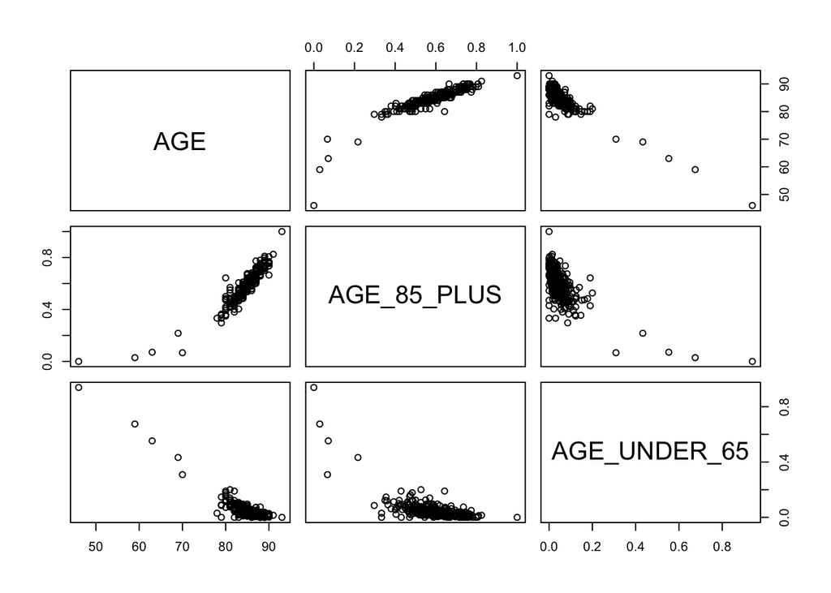

```r
# assess age
age <- c('AGE', 'AGE_85_PLUS', 'AGE_UNDER_65')
pairs(df3[,which(names(df3) %in% age)])
```

```r
cor(df3[,c(10,12,13)], use = "pairwise.complete.obs")
```

```
##                SUB_COMPLAINTS      FEMALE   AGE_85_PLUS
## SUB_COMPLAINTS   1.0000000000 -0.07222021 -0.0007116119
## FEMALE          -0.0722202142  1.00000000  0.4549791113
## AGE_85_PLUS     -0.0007116119  0.45497911  1.0000000000
```

```r
# assess councils
# names(df3)
cor(df3[,c(28:29)])
```

```
##                  RESIDENT_COUNCIL FAMILY_COUNCIL
## RESIDENT_COUNCIL        1.0000000      0.3564071
## FAMILY_COUNCIL          0.3564071      1.0000000
```

```r
df3 <- df3[,-which(names(df3) %in% c("AGE", "AGE_UNDER_65"))]
```

- Convert resident profile information to numeric
- Convert variables to numeric

```r
df3$DEPRESSION <- as.numeric(gsub("[\\%,]", "", df3$DEPRESSION))/100
df3$ADL_DEPENDENT <- as.numeric(gsub("[\\%,]", "", df3$ADL_DEPENDENT))/100
df3$CPS_SEVERE <- as.numeric(gsub("[\\%,]", "", df3$CPS_SEVERE))/100
df3$DEMENTIA <- as.numeric(gsub("[\\%,]", "", df3$DEMENTIA))/100
df3$ABS_PHYS_ABUSIVE <- as.numeric(gsub("[\\%,]", "", df3$ABS_PHYS_ABUSIVE))/100
df3$ISE_LOW <- as.numeric(gsub("[\\%,]", "", df3$ISE_LOW))/100
df3$MEDS_DEPRESSION <- as.numeric(gsub("[\\%,]", "", df3$MEDS_DEPRESSION))/100
df3$MEDS_ANTIPSYCHOTICS <- as.numeric(gsub("[\\%,]", "", df3$MEDS_ANTIPSYCHOTICS))/100
df3$STAY_LENGTH <- as.numeric(gsub("[,]", "", as.character(df3$STAY_LENGTH)))
df3$SUB_COMPLAINTS <- as.numeric(as.character(df3$SUB_COMPLAINTS))
df3$CMI <- as.numeric(as.character(df3$CMI))
```

- Bin values to preserve homes with missing information.

```r
binme <- c("FEMALE", "AGE_85_PLUS", "DEPRESSION", "ADL_DEPENDENT", "CPS_SEVERE", "DEMENTIA", "ABS_PHYS_ABUSIVE",
             "MEDS_DEPRESSION", "MEDS_ANTIPSYCHOTICS", "ISE_LOW", "CMI", "STAY_LENGTH", "SUB_COMPLAINTS",
           "DCH_TOTAL_CURRENTYR")
```

```r
library(OneR)


for (b in binme){
  # print()
  df3[,paste(b, "BIN", sep= "_")] <- bin(df3[,b], nbins = 3, method = "content", na.omit = FALSE)
}

names(df3)
```

```
##  [1] "FACILITY_NAME"             "OWNERSHIP"
##  [3] "REGULATION"                "ACCRED_STATUS"
##  [5] "DCH_TOTAL_CURRENTYR"       "BEDS_TOTAL"
##  [7] "ROOMS_PRIVATE"             "ROOMS_SEMI"
##  [9] "ROOMS_MULTI"               "SUB_COMPLAINTS"
## [11] "FEMALE"                    "AGE_85_PLUS"
## [13] "STAY_LENGTH"               "DEPRESSION"
## [15] "ADL_DEPENDENT"             "CPS_SEVERE"
## [17] "DEMENTIA"                  "ABS_PHYS_ABUSIVE"
## [19] "ISE_LOW"                   "CMI"
## [21] "MEDS_DEPRESSION"           "MEDS_ANTIPSYCHOTICS"
## [23] "INSPECTIONS"               "INFRACTIONS"
## [25] "outbreak"                  "RESIDENT_COUNCIL"
## [27] "FAMILY_COUNCIL"            "BEDS_PRIVATEprop"
## [29] "INCIDENT_OUTBREAK_100_CAT" "INFRACTION_DISEASE_CAT"
## [31] "deaths"                    "FEMALE_BIN"
## [33] "AGE_85_PLUS_BIN"           "DEPRESSION_BIN"
## [35] "ADL_DEPENDENT_BIN"         "CPS_SEVERE_BIN"
## [37] "DEMENTIA_BIN"              "ABS_PHYS_ABUSIVE_BIN"
## [39] "MEDS_DEPRESSION_BIN"       "MEDS_ANTIPSYCHOTICS_BIN"
## [41] "ISE_LOW_BIN"               "CMI_BIN"
## [43] "STAY_LENGTH_BIN"           "SUB_COMPLAINTS_BIN"
## [45] "DCH_TOTAL_CURRENTYR_BIN"
```

Remove non-binned variables for one dataframe and retain only those for another

```r
df3 <- df3[,-c(32:length(df3))]
df_binned <- df3[,-which(names(df3) %in% binme)]
names(df3)
```

```
##  [1] "FACILITY_NAME"             "OWNERSHIP"
##  [3] "REGULATION"                "ACCRED_STATUS"
##  [5] "DCH_TOTAL_CURRENTYR"       "BEDS_TOTAL"
##  [7] "ROOMS_PRIVATE"             "ROOMS_SEMI"
##  [9] "ROOMS_MULTI"               "SUB_COMPLAINTS"
## [11] "FEMALE"                    "AGE_85_PLUS"
## [13] "STAY_LENGTH"               "DEPRESSION"
## [15] "ADL_DEPENDENT"             "CPS_SEVERE"
## [17] "DEMENTIA"                  "ABS_PHYS_ABUSIVE"
## [19] "ISE_LOW"                   "CMI"
## [21] "MEDS_DEPRESSION"           "MEDS_ANTIPSYCHOTICS"
## [23] "INSPECTIONS"               "INFRACTIONS"
## [25] "outbreak"                  "RESIDENT_COUNCIL"
## [27] "FAMILY_COUNCIL"            "BEDS_PRIVATEprop"
## [29] "INCIDENT_OUTBREAK_100_CAT" "INFRACTION_DISEASE_CAT"
## [31] "deaths"
```

### Assess NAs

```r
colSums(is.na.data.frame(df_binned))
```

```
##             FACILITY_NAME                 OWNERSHIP                REGULATION
##                         0                         0                         0
##             ACCRED_STATUS                BEDS_TOTAL             ROOMS_PRIVATE
##                         0                         0                         0
##                ROOMS_SEMI               ROOMS_MULTI               INSPECTIONS
##                         0                         0                         0
##               INFRACTIONS                  outbreak          RESIDENT_COUNCIL
##                         0                         0                         0
##            FAMILY_COUNCIL          BEDS_PRIVATEprop INCIDENT_OUTBREAK_100_CAT
##                         0                         0                         0
##    INFRACTION_DISEASE_CAT                    deaths
##                         0                         0
```

```r
colSums(is.na.data.frame(df3))
```

```
##             FACILITY_NAME                 OWNERSHIP                REGULATION
##                         0                         0                         0
##             ACCRED_STATUS       DCH_TOTAL_CURRENTYR                BEDS_TOTAL
##                         0                         1                         0
##             ROOMS_PRIVATE                ROOMS_SEMI               ROOMS_MULTI
##                         0                         0                         0
##            SUB_COMPLAINTS                    FEMALE               AGE_85_PLUS
##                        11                         3                         3
##               STAY_LENGTH                DEPRESSION             ADL_DEPENDENT
##                        13                         3                         3
##                CPS_SEVERE                  DEMENTIA          ABS_PHYS_ABUSIVE
##                         3                         3                         3
##                   ISE_LOW                       CMI           MEDS_DEPRESSION
##                         3                         4                         3
##       MEDS_ANTIPSYCHOTICS               INSPECTIONS               INFRACTIONS
##                         3                         0                         0
##                  outbreak          RESIDENT_COUNCIL            FAMILY_COUNCIL
##                         0                         0                         0
##          BEDS_PRIVATEprop INCIDENT_OUTBREAK_100_CAT    INFRACTION_DISEASE_CAT
##                         0                         0                         0
##                    deaths
##                         0
```

### Skewness and Transformations

```r
library(skimr)
```

`BEDS_TOTAL` distribution not imporved with log transform.

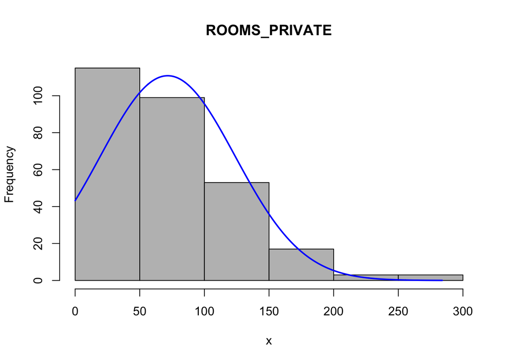

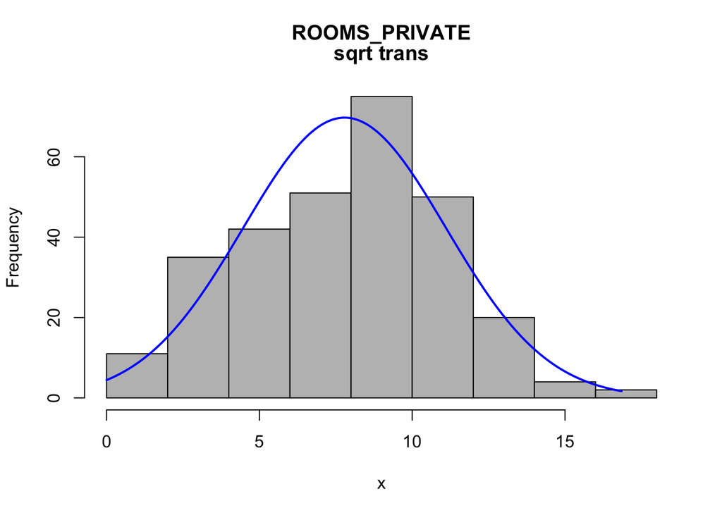

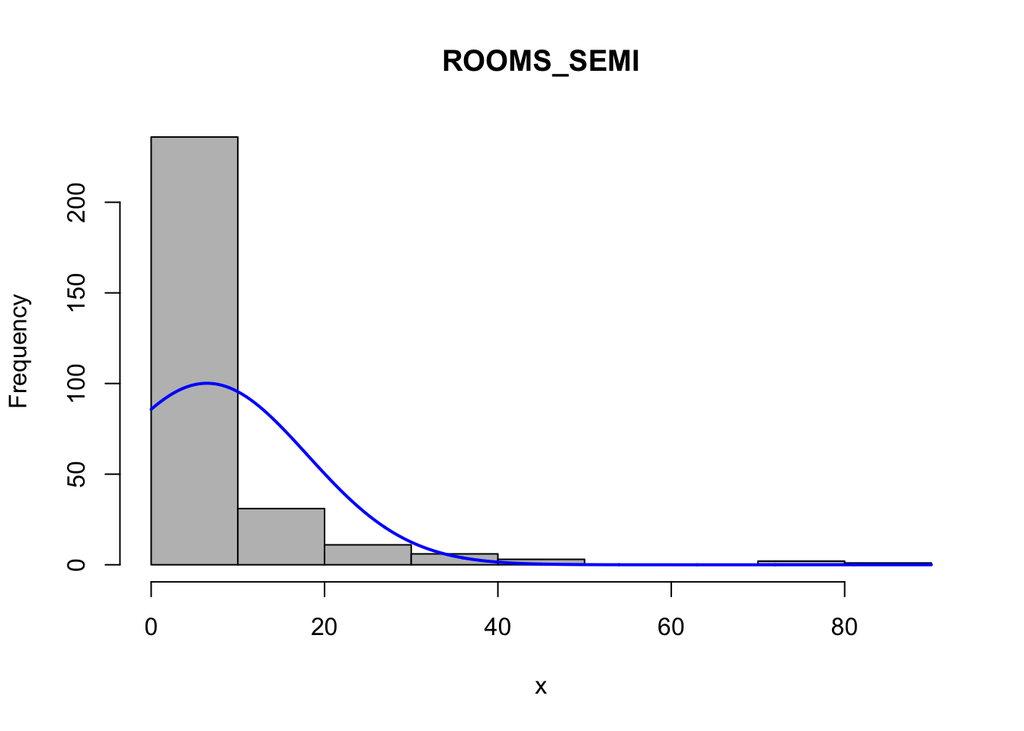

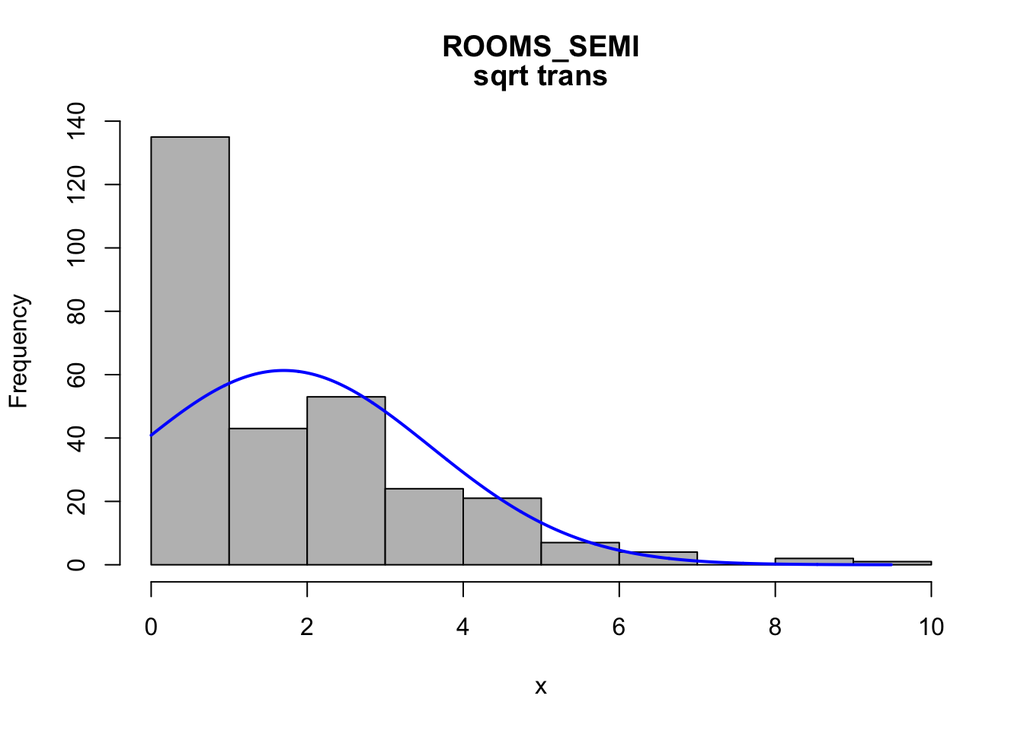

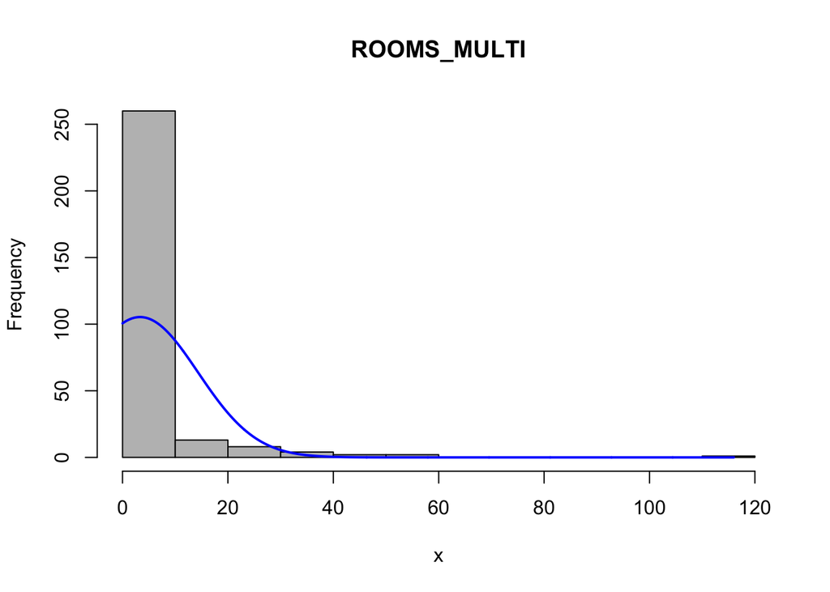

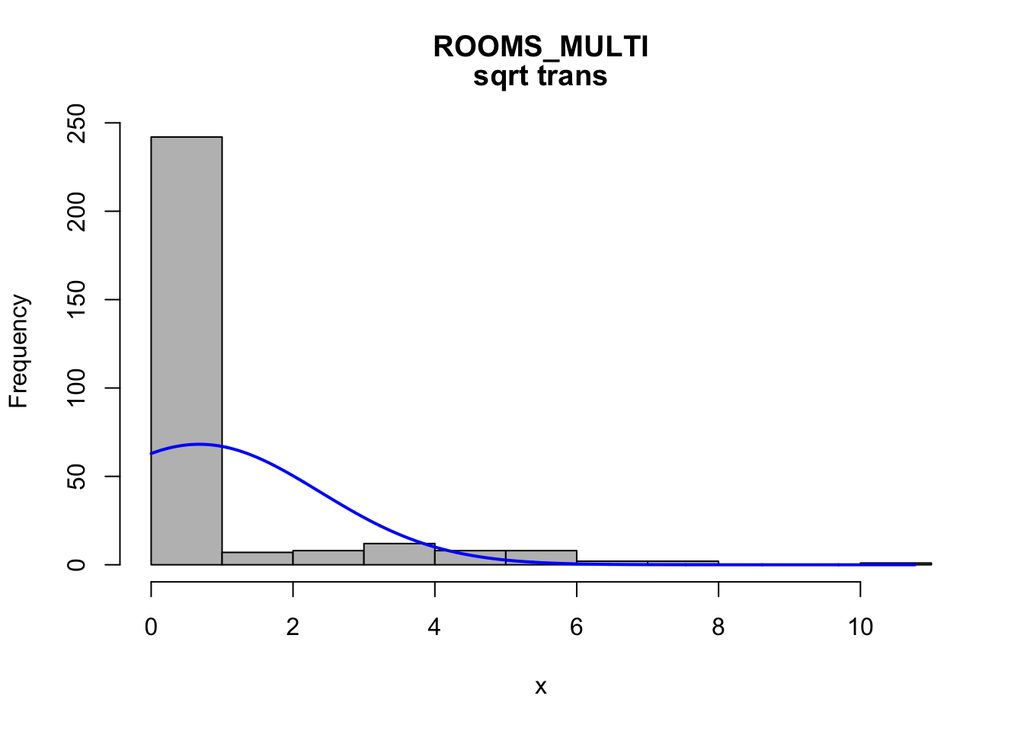

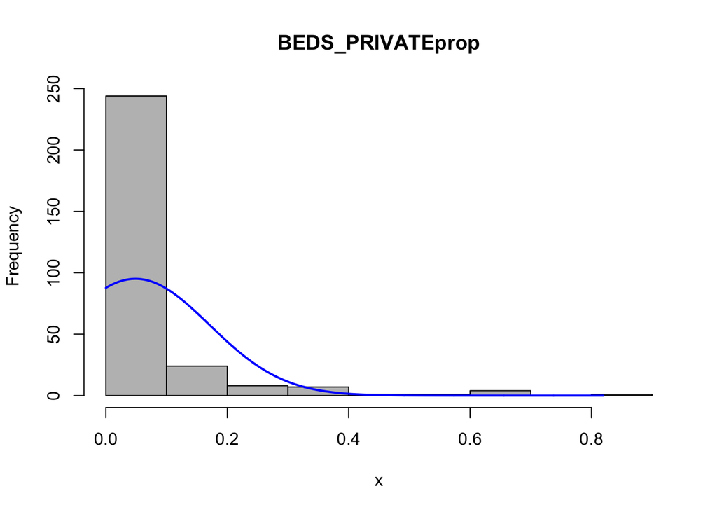

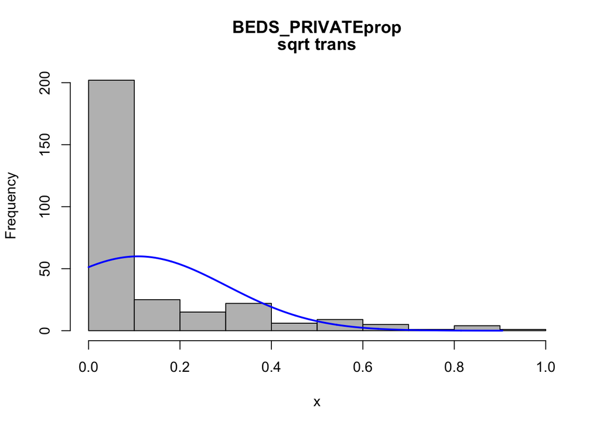

```r
# Create a list of right skewed numeric variables with 0 values
# colSums(df3 == 0)

list_non0s = c('BEDS_TOTAL')
list0s = c("ROOMS_PRIVATE", "ROOMS_SEMI", "ROOMS_MULTI",
  "BEDS_PRIVATEprop")


library(rcompanion)

# Visualize the effect of square root transformations on the numeric predictors
for (each in list0s) {
  plotNormalHistogram(x = df_binned[[each]], main = each)
  plotNormalHistogram(x = sqrt(df_binned[[each]]), main = c(each, 'sqrt trans'))
}
```

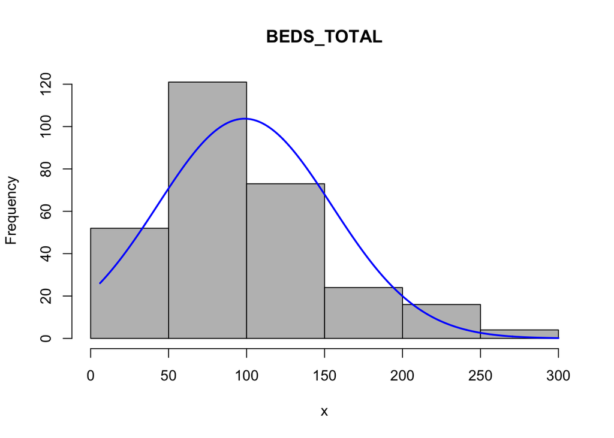

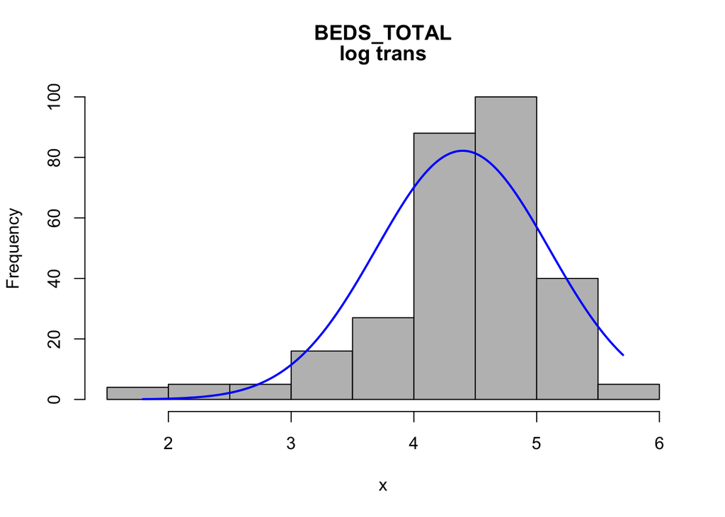

```r
# Visualize the effect of log transformations on the data with no 0s that are right skewed
for (each in list_non0s) {
  plotNormalHistogram(x = df_binned[[each]], main = each)
  plotNormalHistogram(x = log(df_binned[[each]]), main = c(each, 'log trans'))
}
```

Apply transformations where suitable.

```r
df3[list0s] <- sqrt(df3[list0s])

df_binned[list0s] <- sqrt(df_binned[list0s])

skim(df_binned)
```

Data summary

| Name | df_binned |
| --- | --- |
| Number of rows | 290 |
| Number of columns | 17 |
| _______________________ |  |
| Column type frequency: |  |
| factor | 7 |
| logical | 2 |
| numeric | 8 |
| ________________________ |  |
| Group variables | None |

**Variable type: factor**

| skim_variable | n_missing | complete_rate | ordered | n_unique | top_counts |
| --- | --- | --- | --- | --- | --- |
| FACILITY_NAME | 0 | 1 | FALSE | 290 | Abe: 1, Aca: 1, Acr: 1, Ada: 1 |
| OWNERSHIP | 0 | 1 | FALSE | 3 | HA: 107, PFP: 101, PNP: 82 |
| REGULATION | 0 | 1 | FALSE | 3 | Com: 193, Hos: 89, Hos: 8 |
| ACCRED_STATUS | 0 | 1 | FALSE | 3 | Acc: 195, Unk: 61, Not: 34 |
| INCIDENT_OUTBREAK_100_CAT | 0 | 1 | FALSE | 3 | 0: 149, >0: 119, unk: 22 |
| INFRACTION_DISEASE_CAT | 0 | 1 | FALSE | 2 | 0: 242, >0: 48, unk: 0 |
| deaths | 0 | 1 | FALSE | 3 | no : 256, FAL: 17, TRU: 17 |

**Variable type: logical**

| skim_variable | n_missing | complete_rate | mean | count |
| --- | --- | --- | --- | --- |
| RESIDENT_COUNCIL | 0 | 1 | 0.90 | TRU: 262, FAL: 28 |
| FAMILY_COUNCIL | 0 | 1 | 0.85 | TRU: 247, FAL: 43 |

**Variable type: numeric**

| skim_variable | n_missing | complete_rate | mean | sd | p0 | p25 | p50 | p75 | p100 | hist |
| --- | --- | --- | --- | --- | --- | --- | --- | --- | --- | --- |
| BEDS_TOTAL | 0 | 1 | 98.72 | 55.78 | 6 | 61.25 | 90.50 | 125.00 | 300.00 | ▅▇▃▂▁ |
| ROOMS_PRIVATE | 0 | 1 | 7.79 | 3.32 | 0 | 5.57 | 8.19 | 10.10 | 16.85 | ▂▅▇▅▁ |
| ROOMS_SEMI | 0 | 1 | 1.70 | 1.89 | 0 | 0.00 | 1.41 | 2.83 | 9.49 | ▇▅▂▁▁ |
| ROOMS_MULTI | 0 | 1 | 0.68 | 1.70 | 0 | 0.00 | 0.00 | 0.00 | 10.77 | ▇▁▁▁▁ |
| INSPECTIONS | 0 | 1 | 2.62 | 2.79 | 0 | 1.00 | 2.00 | 3.00 | 19.00 | ▇▂▁▁▁ |
| INFRACTIONS | 0 | 1 | 3.77 | 4.35 | 0 | 1.00 | 3.00 | 5.00 | 34.00 | ▇▂▁▁▁ |
| outbreak | 0 | 1 | 0.12 | 0.32 | 0 | 0.00 | 0.00 | 0.00 | 1.00 | ▇▁▁▁▁ |
| BEDS_PRIVATEprop | 0 | 1 | 0.11 | 0.19 | 0 | 0.00 | 0.00 | 0.17 | 0.91 | ▇▁▁▁▁ |

# Binary Logistic Regression on Original Data (not binned)

Remove `FACILITY_NAME` and `deaths`

```r
df4 <- df3[,-which(names(df3) %in% c("FACILITY_NAME", "deaths"))]
df_bin_glm <- df_binned[,-which(names(df_binned) %in% c("FACILITY_NAME", "deaths"))]
```

NAs will be omitted by default.

```r
fit2 = glm(outbreak~., family=binomial, data=df4, maxit = 25)
summary(fit2)
```

```
##
## Call:
## glm(formula = outbreak ~ ., family = binomial, data = df4, maxit = 25)
##
## Deviance Residuals:
##      Min        1Q    Median        3Q       Max
## -2.57200  -0.43044  -0.20823  -0.05788   2.74249
##
## Coefficients:
##                                                                 Estimate
## (Intercept)                                                    1.627e+00
## OWNERSHIPPFP                                                  -1.583e-01
## OWNERSHIPPNP                                                   5.969e-01
## REGULATIONHospital Act                                        -2.668e-01
## REGULATIONHospital Act & Community Care & Assisted Living Act  1.389e+00
## ACCRED_STATUSNot Accredited                                    1.414e+00
## ACCRED_STATUSUnknown                                          -2.344e-01
## DCH_TOTAL_CURRENTYR                                           -5.213e-01
## BEDS_TOTAL                                                     2.685e-02
## ROOMS_PRIVATE                                                 -6.373e-02
## ROOMS_SEMI                                                    -1.613e-01
## ROOMS_MULTI                                                   -6.322e-02
## SUB_COMPLAINTS                                                -2.827e-01
## FEMALE                                                        -3.973e+00
## AGE_85_PLUS                                                    6.363e+00
## STAY_LENGTH                                                   -3.710e-04
## DEPRESSION                                                    -8.192e+00
## ADL_DEPENDENT                                                 -1.161e+00
## CPS_SEVERE                                                     2.302e+00
## DEMENTIA                                                       6.171e-01
## ABS_PHYS_ABUSIVE                                              -3.557e+00
## ISE_LOW                                                        2.136e+00
## CMI                                                           -6.443e+00
## MEDS_DEPRESSION                                               -1.739e+00
## MEDS_ANTIPSYCHOTICS                                            3.440e+00
## INSPECTIONS                                                    6.780e-02
## INFRACTIONS                                                   -1.206e-01
## RESIDENT_COUNCILTRUE                                           6.488e-01
## FAMILY_COUNCILTRUE                                            -1.400e+00
## BEDS_PRIVATEprop                                               1.378e+00
```

[output cut: 101 more lines]

```
## BEDS_PRIVATEprop
## INCIDENT_OUTBREAK_100_CAT0
## INCIDENT_OUTBREAK_100_CATunknown
## INFRACTION_DISEASE_CAT0
## ---
## Signif. codes:  0 '***' 0.001 '**' 0.01 '*' 0.05 '.' 0.1 ' ' 1
##
## (Dispersion parameter for binomial family taken to be 1)
##
##     Null deviance: 204.96  on 271  degrees of freedom
## Residual deviance: 136.92  on 239  degrees of freedom
##   (18 observations deleted due to missingness)
## AIC: 202.92
##
## Number of Fisher Scoring iterations: 17
```

```r
car::vif(fit2)
```

```
##                               GVIF Df GVIF^(1/(2*Df))
## OWNERSHIP                 3.800727  2        1.396261
## REGULATION                3.694392  2        1.386391
## ACCRED_STATUS             2.257268  2        1.225733
## DCH_TOTAL_CURRENTYR       2.048950  1        1.431415
## BEDS_TOTAL                4.878884  1        2.208820
## ROOMS_PRIVATE             5.770506  1        2.402188
## ROOMS_SEMI                2.526158  1        1.589389
## ROOMS_MULTI               5.042923  1        2.245645
## SUB_COMPLAINTS            2.590602  1        1.609535
## FEMALE                    2.221648  1        1.490519
## AGE_85_PLUS               2.749816  1        1.658257
## STAY_LENGTH               1.578089  1        1.256220
## DEPRESSION                1.557499  1        1.247998
## ADL_DEPENDENT             2.402093  1        1.549869
## CPS_SEVERE                2.028357  1        1.424204
## DEMENTIA                  1.818666  1        1.348579
## ABS_PHYS_ABUSIVE          1.959902  1        1.399965
## ISE_LOW                   1.593759  1        1.262442
## CMI                       2.656266  1        1.629806
## MEDS_DEPRESSION           1.748780  1        1.322415
## MEDS_ANTIPSYCHOTICS       1.936730  1        1.391665
## INSPECTIONS               3.017596  1        1.737123
## INFRACTIONS               2.376791  1        1.541685
## RESIDENT_COUNCIL          2.352792  1        1.533881
## FAMILY_COUNCIL            1.820559  1        1.349281
## BEDS_PRIVATEprop          1.956613  1        1.398790
## INCIDENT_OUTBREAK_100_CAT 1.303660  2        1.068541
## INFRACTION_DISEASE_CAT    1.534472  1        1.238738
```

**Should account for multicollinearity.**

```r
library(glmnet)
```

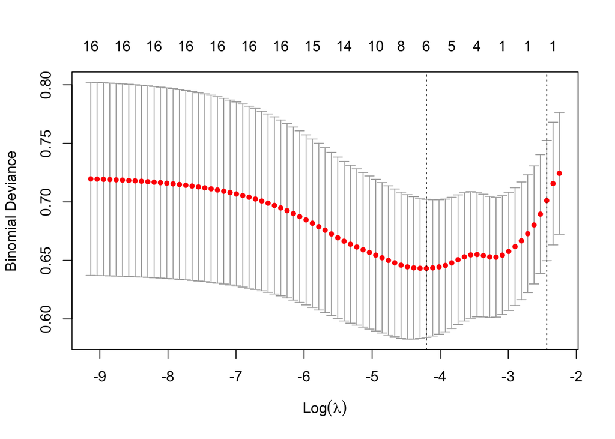

```r
# df_noNA <- na.omit(df4)

x <- model.matrix(outbreak~., df_bin_glm)[,-10]
y <- df_bin_glm$outbreak
cv.lasso <- cv.glmnet(x, y, alpha = 1, family = "binomial")
plot(cv.lasso)
```

```r
coef(cv.lasso, cv.lasso$lambda.min)
```

```
## 20 x 1 sparse Matrix of class "dgCMatrix"
##                                                                         1
## (Intercept)                                                   -3.31372384
## (Intercept)                                                    .
## OWNERSHIPPFP                                                   .
## OWNERSHIPPNP                                                   0.33930075
## REGULATIONHospital Act                                         .
## REGULATIONHospital Act & Community Care & Assisted Living Act  .
## ACCRED_STATUSNot Accredited                                    0.44295109
## ACCRED_STATUSUnknown                                           .
## BEDS_TOTAL                                                     0.01389651
## ROOMS_PRIVATE                                                  .
## ROOMS_MULTI                                                    .
## INSPECTIONS                                                    .
## INFRACTIONS                                                    .
## RESIDENT_COUNCILTRUE                                           .
## FAMILY_COUNCILTRUE                                            -0.56373570
## BEDS_PRIVATEprop                                               0.27967393
## INCIDENT_OUTBREAK_100_CAT0                                     .
## INCIDENT_OUTBREAK_100_CATunknown                              -0.78923705
## INFRACTION_DISEASE_CAT0                                        .
## INFRACTION_DISEASE_CATunknown                                  .
```

Generally, the purpose of regularization is to balance accuracy and simplicity. This means, a model with the smallest number of predictors that also gives a good accuracy. To this end, the function cv.glmnet() finds also the value of lambda that gives the simplest model but also lies within one standard error of the optimal value of lambda. This value is called lambda.1se

```r
coef(cv.lasso, cv.lasso$lambda.1se)
```

```
## 20 x 1 sparse Matrix of class "dgCMatrix"
##                                                                          1
## (Intercept)                                                   -2.320160067
## (Intercept)                                                    .
## OWNERSHIPPFP                                                   .
## OWNERSHIPPNP                                                   .
## REGULATIONHospital Act                                         .
## REGULATIONHospital Act & Community Care & Assisted Living Act  .
## ACCRED_STATUSNot Accredited                                    .
## ACCRED_STATUSUnknown                                           .
## BEDS_TOTAL                                                     0.002945971
## ROOMS_PRIVATE                                                  .
## ROOMS_MULTI                                                    .
## INSPECTIONS                                                    .
## INFRACTIONS                                                    .
## RESIDENT_COUNCILTRUE                                           .
## FAMILY_COUNCILTRUE                                             .
## BEDS_PRIVATEprop                                               .
## INCIDENT_OUTBREAK_100_CAT0                                     .
## INCIDENT_OUTBREAK_100_CATunknown                               .
## INFRACTION_DISEASE_CAT0                                        .
## INFRACTION_DISEASE_CATunknown                                  .
```

# Group LASSO on Original (unbinned) Data

```r
library(grpreg)
```

Assign variables to group domains

```r
home_info <- c("OWNERSHIP", "REGULATION", "ACCRED_STATUS", "BEDS_TOTAL",
               "ROOMS_PRIVATE", "ROOMS_SEMI", "ROOMS_MULTI", "BEDS_PRIVATEprop",
               "RESIDENT_COUNCIL", "FAMILY_COUNCIL")

resident_info <- c("FEMALE", "AGE_85_PLUS", "DEPRESSION", "ADL_DEPENDENT",
                   "CPS_SEVERE", "DEMENTIA","ABS_PHYS_ABUSIVE", "ISE_LOW",
                   "CMI", "MEDS_DEPRESSION", "MEDS_ANTIPSYCHOTICS")

care_quality <- c("INSPECTIONS", "INFRACTIONS", "INCIDENT_OUTBREAK_100_CAT", "INFRACTION_DISEASE_CAT", "SUB_COMPLAINTS", "DCH_TOTAL_CURRENTYR", "STAY_LENGTH") ## HOW to categorize stay_length?
```

```r
df_noNA <- na.omit(df4)
X <- model.matrix(outbreak~., data=df_noNA)[,-24]
Y <- df_noNA$outbreak
dim(X)
```

```
## [1] 272  33
```

```r
n <- colnames(X)
g <- c()

for (i in 1:length(n)){
  g[i] <- ifelse(n[i] %in% home_info, "homeinfo",
                 ifelse(n[i] %in% resident_info, "residentinfo",
                        ifelse(n[i] %in% care_quality, "carequality", "misc")))
  }


group<-as.factor(g)
```

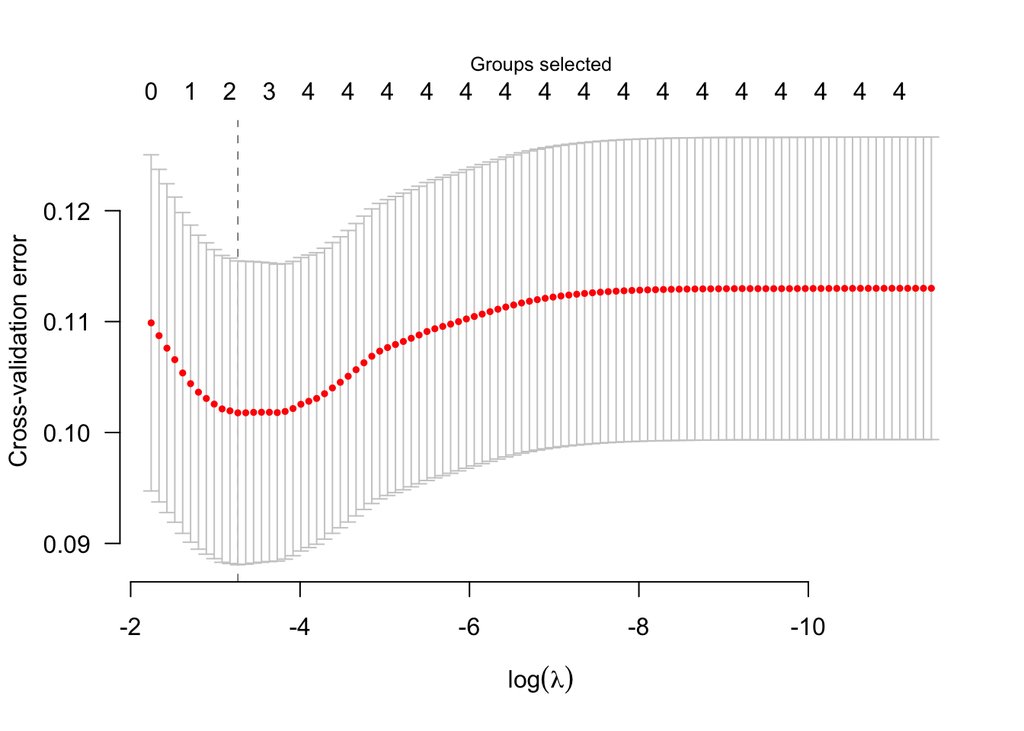

```r
groupfit <- cv.grpreg(X, Y, group, penalty="cMCP")
plot(groupfit)
```

```r
summary(groupfit, "AIC")
```

```
## cMCP-penalized linear regression with n=272, p=33
## At minimum cross-validation error (lambda=0.0382):
## -------------------------------------------------
##   Nonzero coefficients: 3
##   Nonzero groups: 3
##   Cross-validation error of 0.10
##   Maximum R-squared: 0.07
##   Maximum signal-to-noise ratio: 0.07
##   Scale estimate (sigma) at lambda.min: 0.319
```

```r
predict(groupfit, type="groups", lambda=groupfit$lambda.min)# Identity of nonzero groups
```

```
## [1] "homeinfo"     "residentinfo" "misc"
```

```r
predict(groupfit, type="vars", lambda=groupfit$lambda.min)# Identity of nonzero coefficients
```

```
##         BEDS_TOTAL         DEPRESSION FAMILY_COUNCILTRUE
##                  9                 17                 28
```